Project and Conquer!

Bryan W Lewis  
rstor.io  
http://illposed.net

Point of view matters

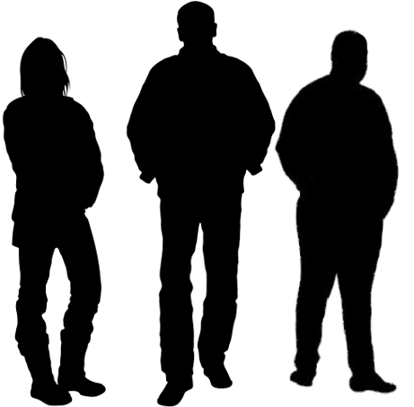

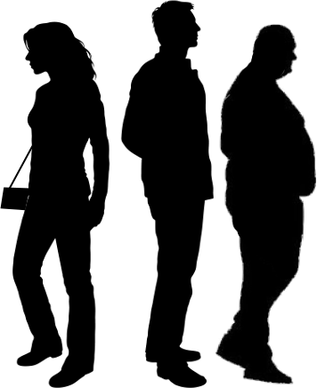

Data Shadows

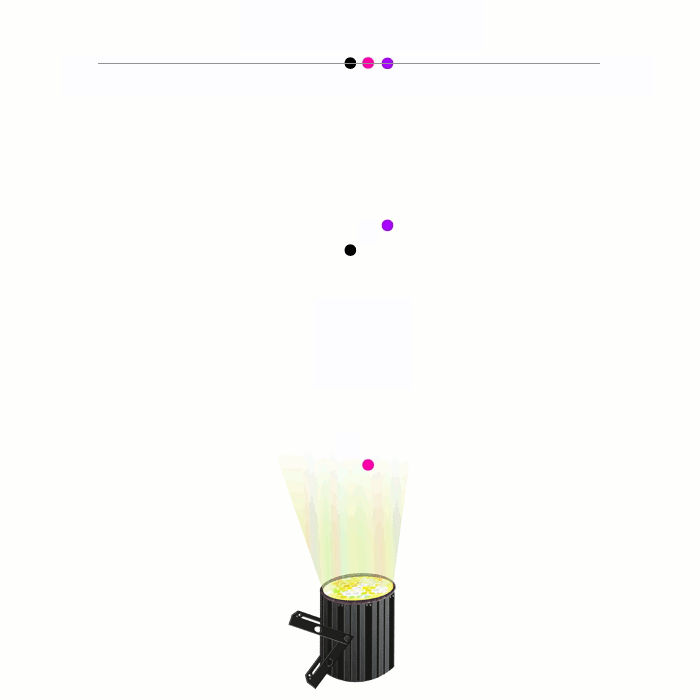

The purple and pink dots are *at least* this far apart.

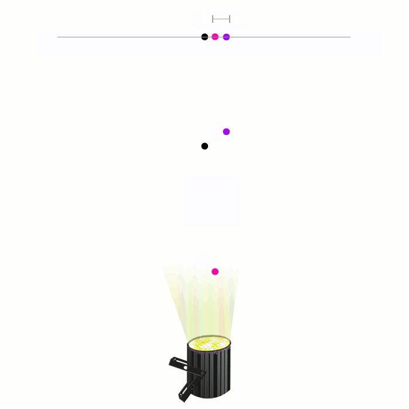

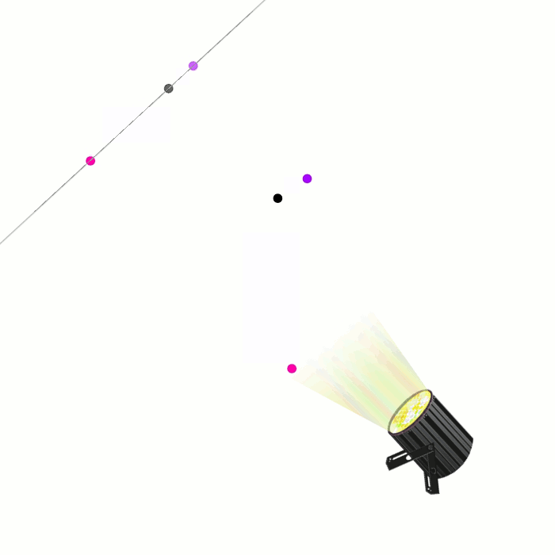

The purple and pink dots are *at least* this far apart.

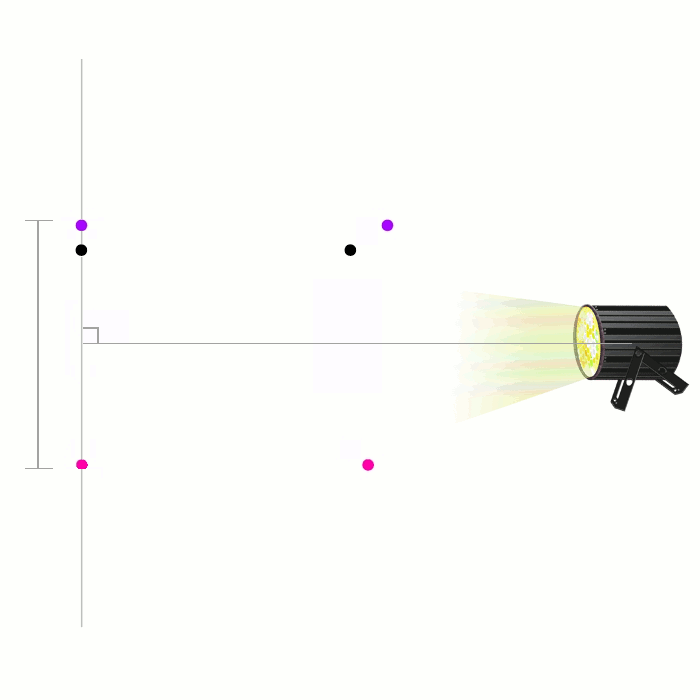

The *tcor* algorithm: fast thresholded distances and correlations.

https://github.com/bwlewis/tcor

http://arxiv.org/abs/1512.07246

# Example

1,000 × 20,522 matrix, find all pairs of columns with Pearson’s correlation coefficient ≥ 0.99.

- brute force needs > 200 GFlops
- tcor solves exactly the same problem using about 1 GFlop<sup>1</sup> *(in seconds on a laptop)*
- easily extends to distributed and arbitrarily large data

<sup>1</sup>For the data matrix described in the package vingette

# Recall, point of view matters

What subspaces to project into?  
What kinds of projections?

# I prefer Krylov subspaces

$$\mathrm{span}(\beta, X\beta, X^2\beta, \ldots, X^{k-1}\beta),$$

$$\mathrm{span}(\beta, X^TX\beta, (X^TX)^2\beta, \ldots, (X^TX)^{k-1}\beta), \qquad \ldots$$

**Random** β for data exploration,  
**measured** β for supervised models

# What other applications?

…focus on the information content (PCA, SVD, etc.)…

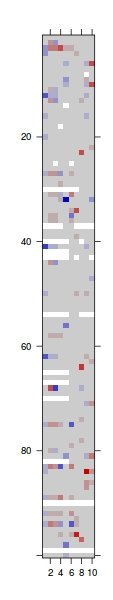

(https://cran.r-project.org/package=irlba)

…or perhaps cluster similar features…

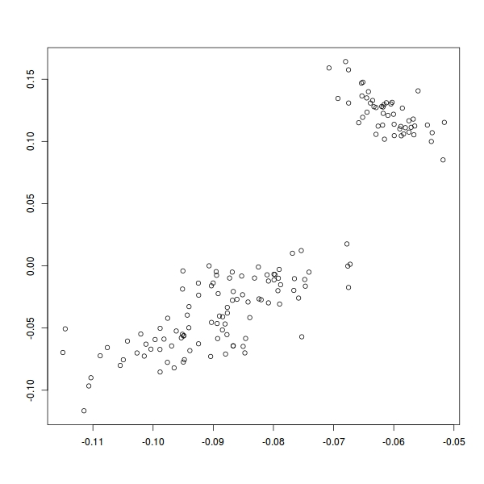

(also https://cran.r-project.org/package=irlba)

…or maybe bi-cluster similar rows and columns…

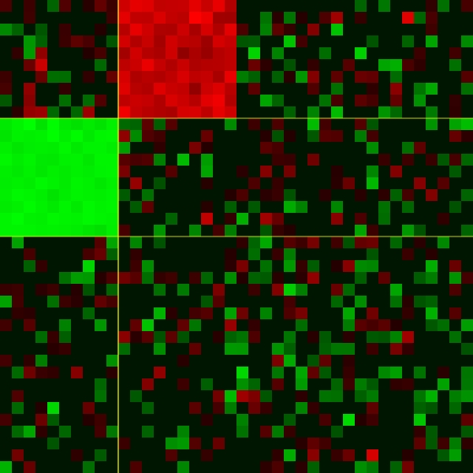

https://CRAN.R-project.org/package=s4vd (Kaiser & Sill)

Sparse biclust algorithm by Lee, Shen, Huang, and Marron

1,000 $\times$ 10,000 example matrix timed on a cheap laptop

```r
library(s4vd)
set.seed(1)
x = matrix(rnorm(1000 * 10000), nrow=1000)
i = seq(from=1, to=nrow(x), by=2)
j = seq(from=1, to=ncol(x), by=2)
x[i,j] = rnorm(length(i)*length(j), mean=2, sd=0.5)
cl = biclust(x, method=BCssvd, K=1)
```

```
- Original routines      3,522s

- Reformulated routines     20s
```

…maybe the data represent a network…

[interactive chart not shown]

…we might desire the most central vertices,

[interactive chart not shown]

or perhaps the most communicable paths, etc….

[interactive chart not shown]

# Kleinberg hub-authority centrality

https://github.com/bwlewis/rfinance-2017/topm.r

Compare to Padé approximant for 1000 × 1000 directed-network adjacency matrix

```r
system.time(ex <- diag(expm(X) + expm(-X)) / 2)
# user    system elapsed
# 151.080 0.220  151.552

head(order(ex, decreasing=TRUE), 5)
#[1] 11 25 27 29 74
```

```r
system.time(top <- topm(X, type="centrality"))
# user  system elapsed
# 0.555 0.010  0.565

top$hubs
#[1] 11 25 27 29 74
```

# Matrix completion

Cool algorithm by Cai, Candès, Shen, prototype: https://github.com/bwlewis/rfinance-2017/blob/master/svt.r

Input matrix M with missing values every except index set P.
$$\min\,\,\mathrm{rank}(X) \,\,\mathrm{s. t.}\,\, X_P = M_P$$

Input matrix M with missing values every except index set P.
$$\min\,\,\mathrm{rank}(X) \,\,\mathrm{s. t.}\,\, X_P = M_P$$

$$\min\,\,||X||_* \,\,\mathrm{s. t.}\,\, X_P = M_P$$

…or, maybe we want to select interesting features (columns)…

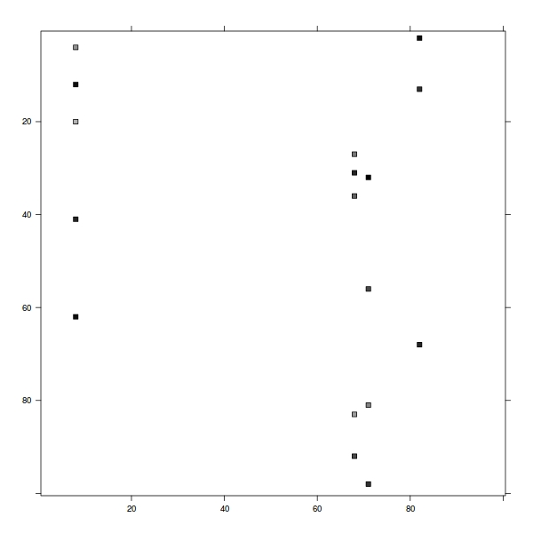

Use generalized Krylov subspaces (Voss, Lanza, Morigi, Reichel, Sgallari, …) to solve

$$\min \frac{1}{p}||X\beta - y||^p_p + \frac{\mu}{q}||\Phi(\beta)||^q_q$$

q = 1 (Lasso) *and* 0 < q < 1 (closer to subset selection!)

# Projection methods turn big data into data

https://bwlewis.github.io/rfinance-2017

https://github.com/bwlewis/rfinance-2017

Thanks, Diethelm!